# Coursera: Regression Models Course Project

Craig Rowley

December 19, 2014

# Executive Summary

I work for Motor Trend (MT), a magazine about the automobile industry. Looking at a data set of a collection of cars, MT is interested in exploring the relationship between vehicle attributes and miles per gallon (MPG). Two specific areas (below) are summarized for you, followed by a detailed explanation of our conclusions.

### Is an automatic or manual transmission better for MPG?

Our analysis shows that a manual transmission correlates with increased fuel efficiency. Transmission alone is not the best way to increase fuel efficiency. Here are some other possibilities discovered in the data.

1. Combining an Inline-engine and fewer Carburetors with a Manual tranmission may also help increase MPG. On average, these cars may get up to 29 MPG, with typical manual transmissions . Toyota Corolla, Fiat, and Datsun do well here.
2. The number of cylinders in a car also does a good job of indicating fuel efficiency. A 4-cylinder car can commonly have up to 10 mpg increase over an 8-cylinder vehicle. Average MPG ranges between 15 and 26 mpg for highest and lowest cylinder counts, respectively.

### Quantify the MPG difference between automatic and manual transmissions.

Using a model that considers only engine type (V or Inline) and the number of Carburetors, we can quantify the mpg increase attributable to a manual transmission. If we train the same model on two mutually exclusive data sets (automatic versus manual transmission), we see that a *manual transmission get more than 7 mpg better fuel efficiency*. Switching to an Inline engine has a more positive effect on automatics (+4.34 mpg), but that is insufficient to overtake the manual transmission. In fact, our model suggests that a manual transmission could opt for more power by switching to a V-engine and dual Carbs and still likely outperform the fuel efficiency of the average automatic (if they weren’t racing or hauling loads).

```r
at <- mtcars[mtcars$am==0,c("mpg","vs","carb")]; lm_at <- lm(mpg ~ ., at)
mt <- mtcars[mtcars$am==1,c("mpg","vs","carb")]; lm_mt <- lm(mpg ~ ., mt)
coef(lm_at); coef(lm_mt)
```

```
## (Intercept)          vs        carb
##   19.461710    4.347200   -1.430825
```

```
## (Intercept)          vs        carb
##   26.738430    3.772314   -1.497521
```

# Model Design

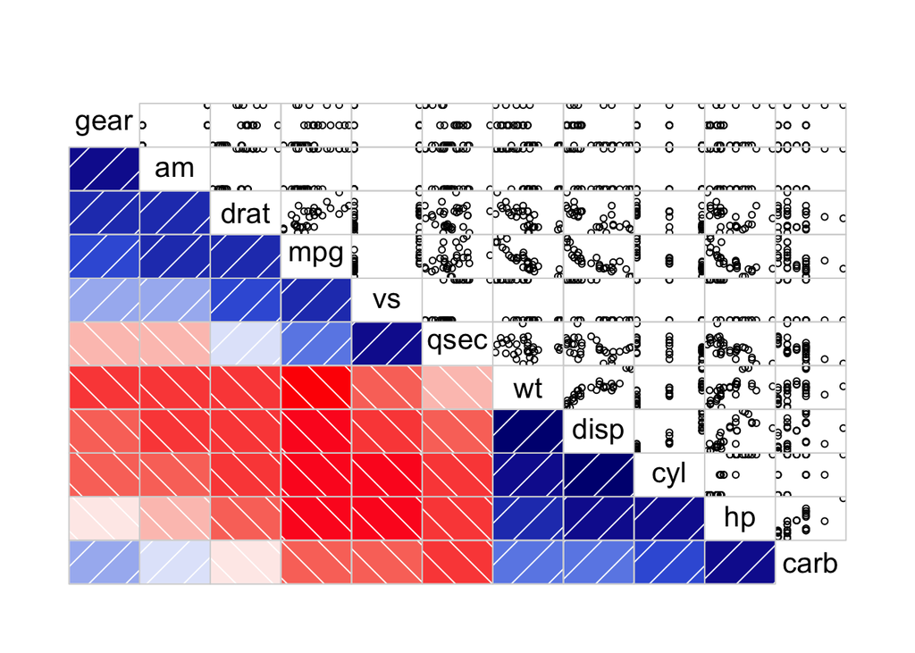

Thoughts on Correlation:

```r
ks<-lm(mpg~.,mtcars); sort(coef(ks),decreasing=TRUE); sqrt(vif(ks))
```

```
## (Intercept)          am        qsec        drat        gear          vs
## 12.30337416  2.52022689  0.82104075  0.78711097  0.65541302  0.31776281
##        disp          hp         cyl        carb          wt
##  0.01333524 -0.02148212 -0.11144048 -0.19941925 -3.71530393
```

```
##      cyl     disp       hp     drat       wt     qsec       vs       am
## 3.920948 4.649757 3.135608 1.837014 3.894212 2.743712 2.228424 2.156035
##     gear     carb
## 2.314617 2.812249
```

Thoughts on Kitchen Sink model Coefficients (above):

- Increased Weight, Carburetor count, Cylinder count, and Horsepower result in less MPG
- Increased Displacement, Straight engine, gears, Rear axle ratio, and Manual trany result in higher MPG
- Quarter-mile time does “not” match intuition as faster acceleration should have negative impact on MPG

Thoughts on Colinearity (above) :

- Variance inflation factors all reasonably high (too many variables)
- Weight is correlated, but we find that it has Heteroskedascity issues with mpg (see Appendix)

# Appendix: Exploratory Data Analysis (output grossly reduced to meet 5 page requirement)

Omitted Variables (due to 5-page limit) :: disp, drat, hp, qsec, gear

## Critical Variables

### mpg :: Miles/(US) gallon

Our Dependent Variable.

### cyl :: Number of cylinders

Larger, more powerful vehicles typically have more cylinders. More cylinders typically means more fuel-per-second consumed in modern cars (and more horsepower), but have a negative impact on mpg.

```r
#...Model and output interesting EDA
fit <- lm(mpg ~ cyl, mtcars)
summary(fit)$r.squared
```

```
## [1] 0.72618
```

### wt :: Weight (lb/1000)

Weight of vehicle expressed in units of 1k lbs. Note that Weight’s residual plot shows non-random U-shape (i.e. Heteroskedasticity)

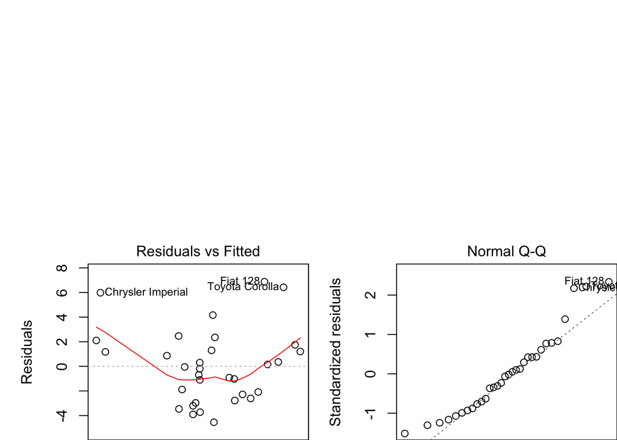

```r
fit <- lm(mpg ~ wt, mtcars)
par(mfrow=c(1,2),mar=c(0,5,15,0))
plot(fit,which=c(1,2))
```

### am :: Transmission (0 = automatic, 1 = manual)

Manual transmission should help mpg (based on Consumer Reports research)

```r
fit <- lm(mpg ~ am, mtcars)
summary(fit)$r.squared
```

```
## [1] 0.3597989
```

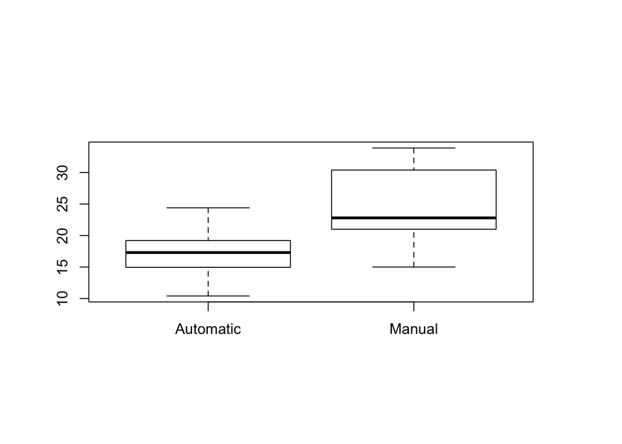

```r
par(mfrow=c(1,1),mar=c(8,5,8,5))
boxplot(mtcars$mpg~mtcars$am,names=c("Automatic","Manual"))
```

### carb :: Number of carburetors

Number of carbs decreases fuel efficiency

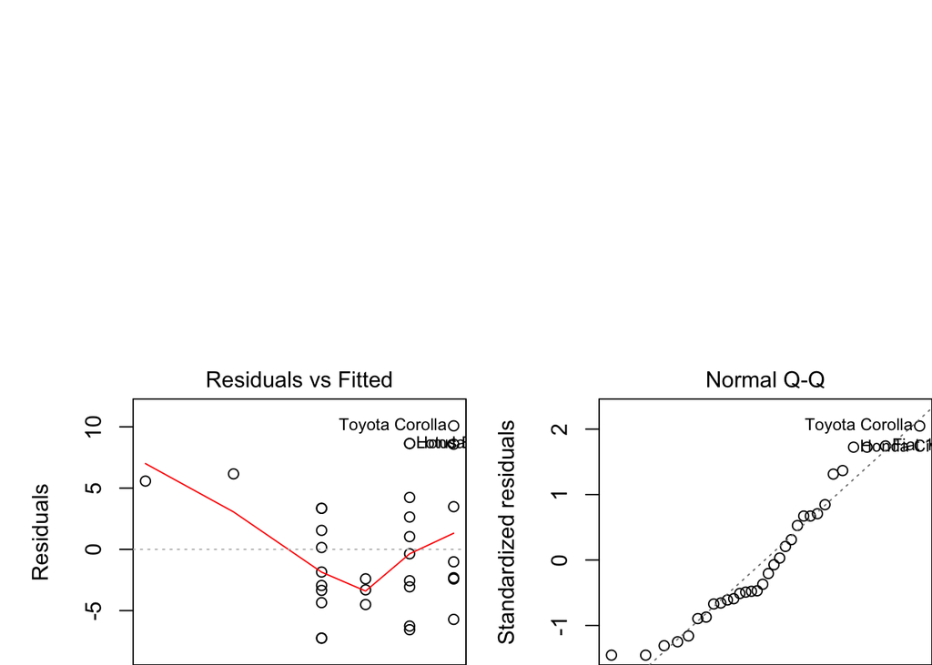

### vs :: V-shaped or Straight (Inline) engine shape

Inline engine increases fuel efficiency

[figure not shown]

## Modeling

### Remove Heteroskedastic, Colinear, and Uncorrelated variables

```r
mtcars_1 <- mtcars[,c("mpg","drat","vs","am","gear","carb")]
model_1 <- lm(mpg ~ ., mtcars_1)
sqrt( vif(model_1) )
```

```
##     drat       vs       am     gear     carb
## 1.685073 1.484628 1.887650 2.076755 1.495089
```

### (Selected Model) Remove Gear and Drat due to correlation

- Coefficients match research and individual trends
- p-values and variable inflation factors are appropriately small
- No significant colinearity issues
- No Heteroskedasticity issues

```r
mtcars_3 <- mtcars[,c("mpg","vs","am","carb")]
model_3 <- lm(mpg ~ ., mtcars_3)
s <- summary(model_3)
s$coefficients
```

```
##              Estimate Std. Error   t value     Pr(>|t|)
## (Intercept) 19.517399  1.6090815 12.129528 1.155904e-12
## vs           4.195736  1.3245867  3.167581 3.695735e-03
## am           6.797956  1.1014890  6.171606 1.154742e-06
## carb        -1.430783  0.4081085 -3.505890 1.552505e-03
```

```r
s$r.squared
```

```
## [1] 0.7818462
```

```r
sqrt(vif(model_3))
```

```
##       vs       am     carb
## 1.254946 1.033173 1.239088
```

### Remove VS since it correlates with am and carb

Thoughts :: R^2 took a dive, so removing VS was not necessary

```r
mtcars_5 <- mtcars[,c("mpg","am","carb")]
model_5 <- lm(mpg ~ ., mtcars_5)
summary(model_5)$r.squared
```

```
## [1] 0.7036726
```